# Multiresolution dissection of phenotype-associated cell states using scAB

Qinran Zhang

3 November, 2022

This demonstration outlines the key steps of scAB. The data consist of single-cell RNA-seq data, Bulk-seq data, and the phenotype of patients in bulk samples, which can be downloaded from Github.

## Load the required libraries

```r
library(Seurat)
library(preprocessCore)
library(scAB)
```

## Load data

The algorithm requires three types of data inputs. Single-cell RNA-seq data is a Seurat object, and bulk RNA-seq data is a digital matrix/data frame. Phenotype data can be a matrix with two columns, time and state, or a vector. Please assign sample names that match the bulk RNA-seq data for phenotype data.

```r
data("data_survival")
dim(sc_dataset)
```

```
#> [1] 21287  8853
```

```r
head(bulk_dataset[,1:10])
```

```
#>           TCGA-2Y-A9GS-01 TCGA-2Y-A9GT-01 TCGA-2Y-A9GU-01 TCGA-2Y-A9GV-01
#> ARHGEF10L         11.5199         12.2544         12.6434         11.9114
#> HIF3A              2.4425          4.6559          1.8083          3.7751
#> RNF17              3.7881          0.0000          0.0000          0.0000
#> RNF10             11.5109         11.7863         12.3187         11.7253
#> RNF11             10.6574         11.0133         10.5722         10.9586
#> RNF13             10.2623         10.4574          9.9284         10.5863
#>           TCGA-2Y-A9GW-01 TCGA-2Y-A9GX-01 TCGA-2Y-A9GY-01 TCGA-2Y-A9GZ-01
#> ARHGEF10L         11.8108         10.6616         10.6321         12.4218
#> HIF3A              2.8340          3.2456          7.1429          5.7972
#> RNF17              0.0000          0.0000          7.9222          0.7507
#> RNF10             11.8382         11.5872         11.5770         11.2699
#> RNF11             10.3071         10.7500          9.9313         10.7820
#> RNF13             10.1785         10.4880         10.0815         10.5819
#>           TCGA-2Y-A9H0-01 TCGA-2Y-A9H1-01
#> ARHGEF10L         10.8164         10.2715
#> HIF3A              3.7561          4.3687
#> RNF17              0.0000          0.0000
#> RNF10             12.7789         11.2257
#> RNF11             10.0653         10.1549
#> RNF13             10.6751          9.9593
```

```r
head(phenotype)
```

```
#>                 time status
#> TCGA-2Y-A9GS-01  724      1
#> TCGA-2Y-A9GT-01 1624      1
#> TCGA-2Y-A9GU-01 1939      0
#> TCGA-2Y-A9GV-01 2532      1
#> TCGA-2Y-A9GW-01 1271      1
#> TCGA-2Y-A9GX-01 2442      0
```

## Preprocessor on Single-cell data

We use functions in the Seurat package to preprocess single-cell RNA-seq data and construct a cell-cell similarity network. In this package, we wrapped preprocess functions from Seurat package into the following function: run_seurat.

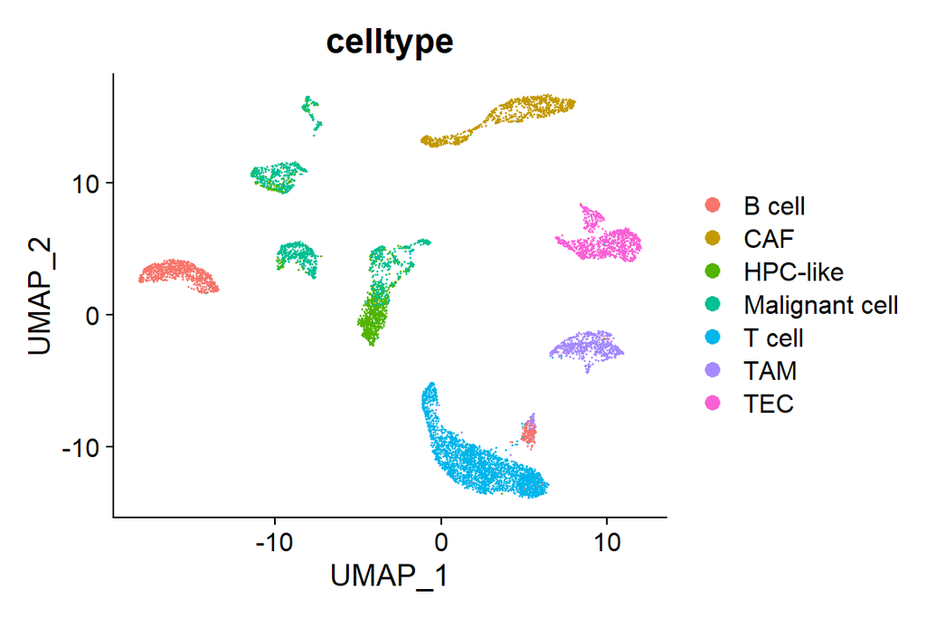

```r
sc_dataset <- run_seurat(sc_dataset,verbose = FALSE)
UMAP_celltype <- DimPlot(sc_dataset, reduction ="umap",group.by="celltype")
UMAP_celltype
```

## Create a scAB object

Run “create_scAB” function to calculate the sample-cell similarity matrix and the score of the sample phenotype.

```r
scAB_data <- create_scAB(sc_dataset,bulk_dataset,phenotype)
```

## Selection of parameter K

The function ‘select_K’ can aid in selecting k. K is a suitable value when the downward trend of reconstruction error slows down.

```r
K <- select_K(scAB_data)
K
```

```
#> [1] 4
```

## Run scAB model

Run the scAB model with default parameters. The regularization parameters α1 and α2 could be also determined using cross-validation method via ‘select_alpha’ function.

```r
scAB_result <- scAB(Object=scAB_data, K=K)
sc_dataset <- findSubset(sc_dataset, scAB_Object = scAB_result, tred = 2)
```

## Visualize the cells associated with the phenotype

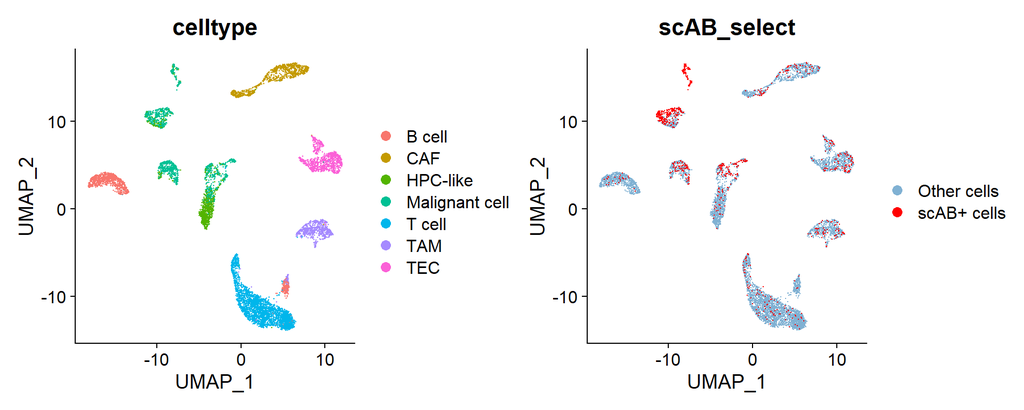

```r
UMAP_scAB <- DimPlot(sc_dataset,group.by="scAB_select",cols=c("#80b1d3","red"),pt.size=0.001,order=c("scAB+ cells","Other cells"))
patchwork::wrap_plots(plots = list(UMAP_celltype,UMAP_scAB), ncol = 2)
```

## Visualize the cell subsets

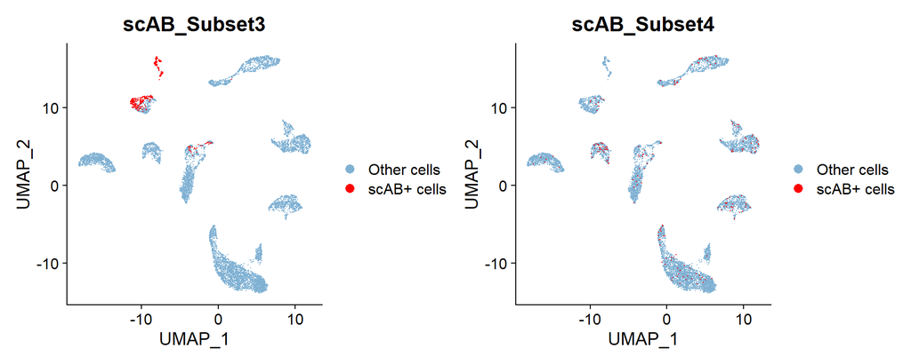

```r
UMAP_subset3 <- DimPlot(sc_dataset,group.by="scAB_Subset3",cols=c("#80b1d3","red"),pt.size=0.001,order=c("scAB+ cells","Other cells"))
UMAP_subset5 <- DimPlot(sc_dataset,group.by="scAB_Subset4",cols=c("#80b1d3","red"),pt.size=0.001,order=c("scAB+ cells","Other cells"))
UMAP_subset <- patchwork::wrap_plots(plots = list(UMAP_subset3,UMAP_subset5), ncol = 2)
UMAP_subset
```

## Identify signature genes

We use log-fold changes of 1 as the cutoff to identify the most differentially expressed signature genes, which is helpful for selecting potential biomarkers. The cutoff value may be dependent on the specific datasets and users can adjust this parameter value. Lower cutoff values lead to more candidate signature genes.

```r
markers <- FindMarkers(sc_dataset, ident.1 = "scAB+ cells", group.by = 'scAB_select', logfc.threshold = 1)
markers <- markers[which(markers$p_val_adj<0.05),]
head(markers)
```

```
#>        p_val avg_log2FC pct.1 pct.2 p_val_adj
#> CFHR1      0   1.690565 0.276 0.014         0
#> TF         0   2.830617 0.420 0.045         0
#> UGT2B4     0   1.033856 0.268 0.014         0
#> GC         0   2.271937 0.478 0.069         0
#> FGB        0   2.327561 0.427 0.053         0
#> FGL1       0   2.114117 0.423 0.049         0
```